# PA1_template.Rmd

Alberto Cortes

December 7, 2016

# # Course Project 1

## Loading and preprocessing the data

Loading .csv file.

```r
data <- read.csv("activity.csv")
```

## What is mean total number of steps taken per day?

The function tapply was used to calculate the number of steps taken per day

```r
totalSteps <- tapply(data$steps, data$date, sum)
```

This is the histogram of the total number of steps taken each day

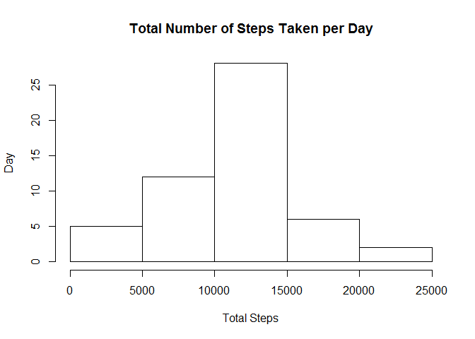

```r
hist(totalSteps, xlab = "Total Steps", ylab = "Day", main = "Total Number of Steps Taken per Day")
```

Mean and Median of the total number of steps taken per day.

```r
mean(totalSteps, na.rm = TRUE)
```

```
## [1] 10766.19
```

```r
median(totalSteps, na.rm = TRUE)
```

```
## [1] 10765
```

## What is the average daily activity pattern

Tapply is used to calculate the average number of steps per 5-minute interval

```r
avgSteps <- tapply(data$steps, data$interval, mean, na.rm = TRUE)
```

Then the 5-minute interval and average number of steps taken is plotted

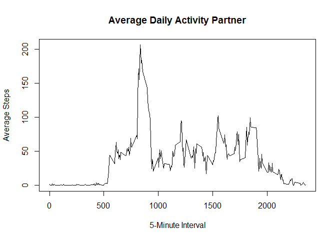

```r
plot(unique(data$interval), avgSteps, type = "l", xlab = "5-Minute Interval", ylab = "Average Steps", main = "Average Daily Activity Partner")
```

which.max is used to show the 5-minute interval with the maximum number of steps

```r
avgSteps[which.max(avgSteps)]
```

```
##      835
## 206.1698
```

## Imputing missing values

Show total number of NA’s in the dataset

```r
sum(is.na(data))
```

```
## [1] 2304
```

Strategy for filling NA’s, it fills all NA’s with 0

```r
tapply(data$steps, data$interval, mean, na.rm = TRUE)
```

[output not shown]

[output cut: 41 more lines]

[output not shown]

Filling NA’s values with 0’s in new dataset

```r
fullData <- data
fullData[is.na(fullData)] <- 0
```

Calculates the number of steps per day

```r
totalNumSteps <- tapply(fullData$steps, fullData$date, sum)
```

Create histogram for total number of steps taken per day

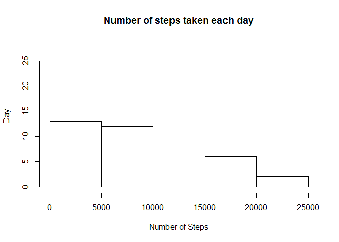

```r
hist(totalNumSteps, xlab = "Number of Steps", ylab = "Day", main = "Number of steps taken each day")
```

Show mean and median of the total number of steps taken per day

```r
mean(totalNumSteps)
```

```
## [1] 9354.23
```

```r
median(totalNumSteps)
```

```
## [1] 10395
```

## Are there differences in activity patterns between weekdays and weekends?

Creates a factor variable of two levels “Weekdays” and “Weekends”

```r
fullData$weekday <- factor(fullData$date, levels = c("Weekdays", "Weekends"))
```

Assigns “Weekday” if the day is between Monday-Friday, if not it assigns “Weekend”

```r
fullData$weekday <- ifelse(weekdays(as.Date(fullData$date)) == "Monday" | weekdays(as.Date(fullData$date)) == "Tuesday" | weekdays(as.Date(fullData$date)) == "Wednesday" | weekdays(as.Date(fullData$date)) == "Thursday" | weekdays(as.Date(fullData$date)) == "Friday", "Weekday", "Weekend")
```

Calculates the average number of steps of each interval across all weekdays or weekend days

```r
avgStepsW <- aggregate(steps ~ interval + weekday, fullData, mean, na.rm = TRUE)
```

Plot the Number of steps of each 5-minute interval per Weekend and per Weekday

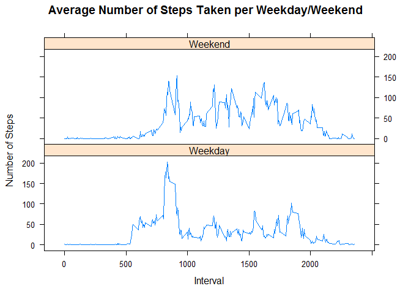

```r
library(lattice)
xyplot(steps ~ interval | weekday, avgStepsW, type = "l", layout = c(1, 2), xlab = "Interval", ylab = "Number of Steps", main = "Average Number of Steps Taken per Weekday/Weekend")
```